# Chapter 8. Smoothing in the time and frequency domains

### A motivated example

Estimating a nonparametric trend from a time series is known as **smoothing**.

```r
# system() invokes the OS command specified by command.
# head displays first line of file.
system("head data/unadjusted_unemployment.csv",intern=TRUE)
```

```
##  [1] "# Data extracted on: February 4, 2016 (10:06:56 AM)"
##  [2] "# from http://data.bls.gov/timeseries/LNU04000000"
##  [3] "# Labor Force Statistics from the Current Population Survey"
##  [4] "# Not Seasonally Adjusted"
##  [5] "# Series title:        (Unadj) Unemployment Rate"
##  [6] "# Labor force status:  Unemployment rate"
##  [7] "# Type of data:        Percent or rate"
##  [8] "# Age:                 16 years and over"
##  [9] "Year,Jan,Feb,Mar,Apr,May,Jun,Jul,Aug,Sep,Oct,Nov,Dec"
## [10] "1948,4.0,4.7,4.5,4.0,3.4,3.9,3.9,3.6,3.4,2.9,3.3,3.6"
```

```r
U1 <- read.table(file="data/unadjusted_unemployment.csv", sep=",",header=TRUE)
head(U1,3)
```

```
##   Year Jan Feb Mar Apr May Jun Jul Aug Sep Oct Nov Dec
## 1 1948 4.0 4.7 4.5 4.0 3.4 3.9 3.9 3.6 3.4 2.9 3.3 3.6
## 2 1949 5.0 5.8 5.6 5.4 5.7 6.4 7.0 6.3 5.9 6.1 5.7 6.0
## 3 1950 7.6 7.9 7.1 6.0 5.3 5.6 5.3 4.1 4.0 3.3 3.8 3.9
```

We first need to extract the data from the table:

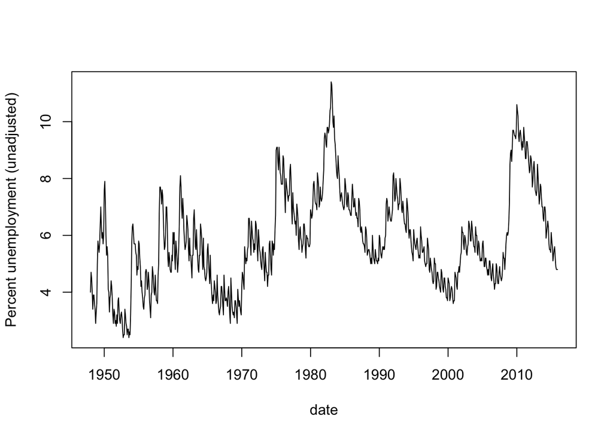

```r
u1 <- t(as.matrix(U1[2:13]))  # t() get transpose of matrix.
dim(u1) <- NULL  # dim() retrieve or set the dimension of an object. Convert marix u1 to an 1D array
date <- seq(from=1948,length=length(u1),by=1/12)  # generate sequence, `by` is increment.
plot(date,u1,type="l",ylab="Percent unemployment (unadjusted)")
```

We can look at monthly seasonally adjusted unemployment:

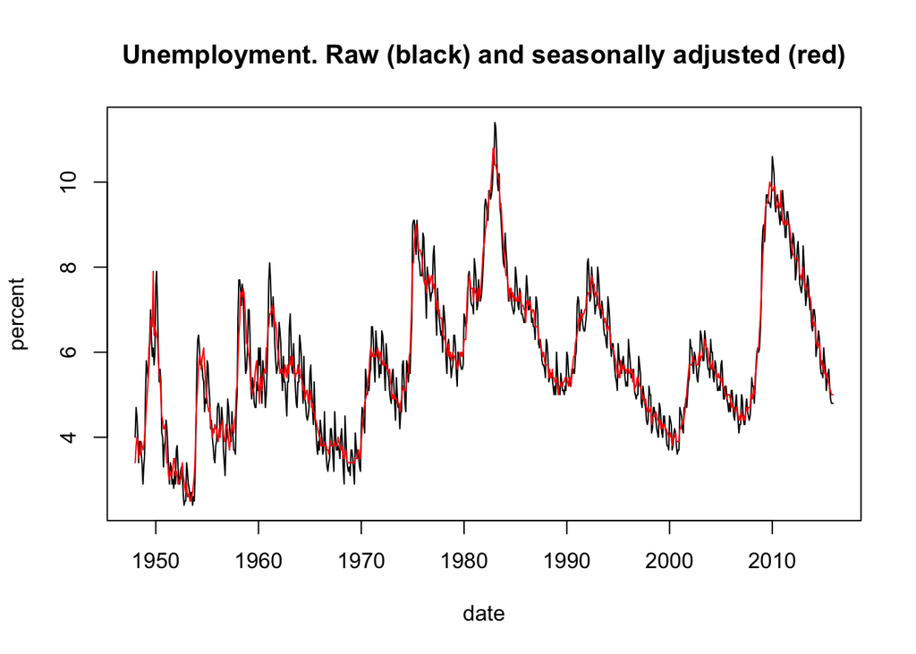

```r
U2 <- read.table(file="data/adjusted_unemployment.csv",sep=",",header=TRUE)
u2 <- t(as.matrix(U2[2:13]))
dim(u2) <- NULL
plot(date,u1,type="l",ylab="percent",col="black")
lines(date,u2,type="l",col="red")
title("Unemployment. Raw (black) and seasonally adjusted (red)")
```

To help understand the seasonal adjustment, we can look at what it does to the smoothed periodogram.

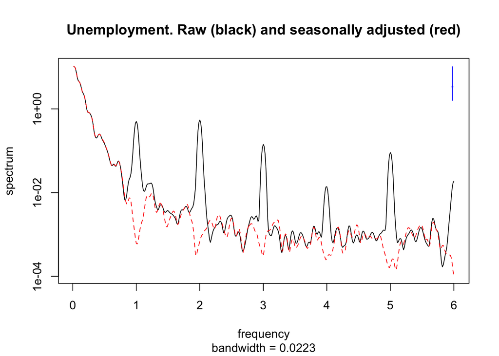

```r
u1_ts <- ts(u1,start=1948,frequency=12)
u2_ts <- ts(u2,start=1948,frequency=12)
# ts.union() bind time series which have a common frequency
spectrum(ts.union(u1_ts,u2_ts),spans=c(3,5,3),main="Unemployment. Raw (black) and seasonally adjusted (red)")
```

- x axis units: cycles per year. (Determined by the range of x. If the unit is cycles per month, the x axis can only go up to $1/2$ not $6$).
- U.S. Bureau of Labor Statistics (BLS) seasonal adjustment removes the **effects of recurring seasonal influences** from economic series.It removes most of the signal at seasonal frequencies and little elsewhere.

### Transfer function / frequecy response

The **ratio of the periodograms of the smoothed and unsmoothed time series** is called the **transfer function or frequency response function of the smoother**.

We can infer the frequency response of the smoother to deseasonalize the data.

```r
s <- spectrum(ts.union(u1_ts,u2_ts),plot=FALSE)
names(s)
```

```
##  [1] "freq"      "spec"      "coh"       "phase"     "kernel"    "df"
##  [7] "bandwidth" "n.used"    "orig.n"    "series"    "snames"    "method"
## [13] "taper"     "pad"       "detrend"   "demean"
```

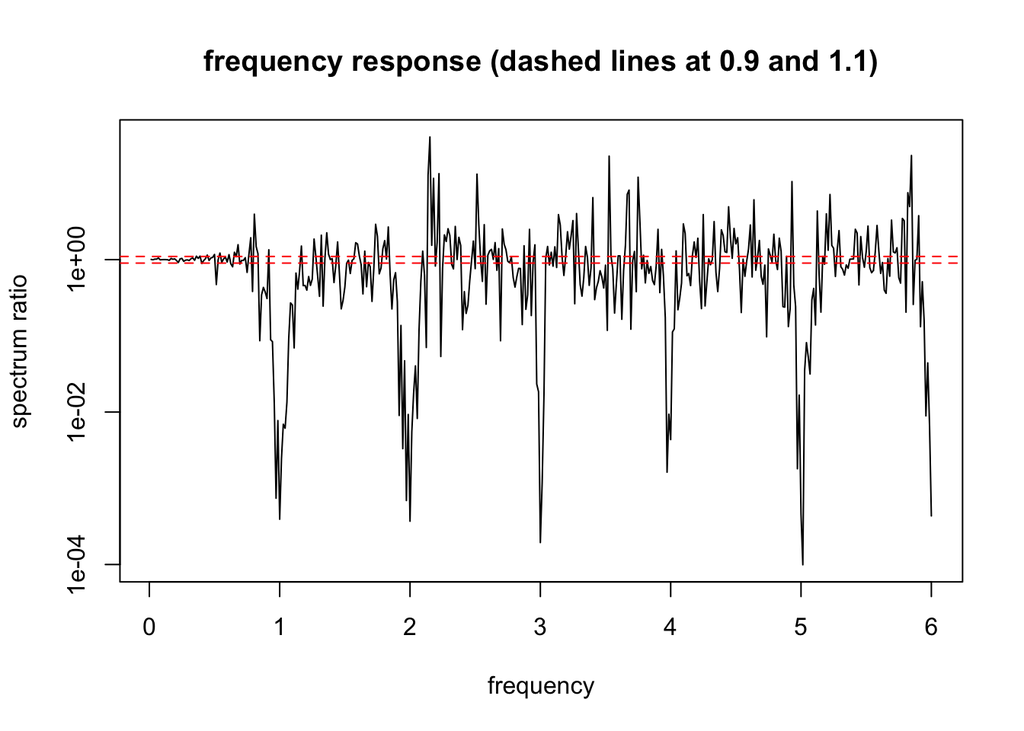

```r
plot(s$freq,s$spec[,2]/s$spec[,1],type="l",log="y",
  ylab="spectrum ratio", xlab="frequency",
  main="frequency response (dashed lines at 0.9 and 1.1)")
abline(h=c(0.9,1.1),lty="dashed",col="red")
```

From this frequency response plot, we can see that the seasonal adjustment removes 3 orders of magnitude from the power of the signal at seasonal frequencies, and some of the power from neighboring frequencies.

### Loess smoothing

Loess is a **Local linear regression** approach. At each point in time, Loess makes a linear regression (e.g., fit a constant, linear or quadratic polynomial) using only points close in time.

It is implemented in R by `loess`, with `span` setting the fraction of points included in the moving window.

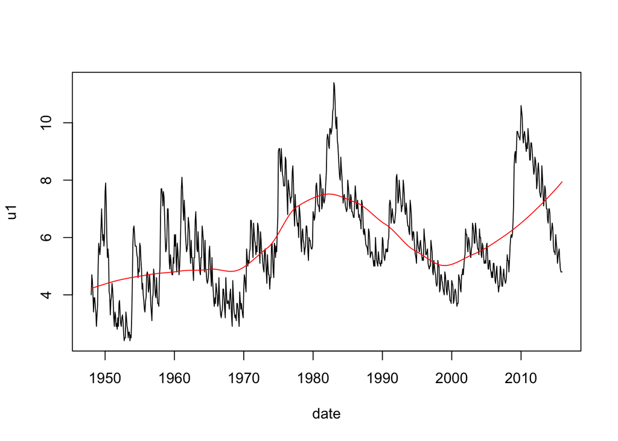

```r
u1_loess <- loess(u1~date,span=0.5)
plot(date,u1,type="l")
lines(u1_loess$x,u1_loess$fitted,type="l",col="red",tck=2)
```

In the plot, at any point $t$, loess looks at $50\%$ of points closest to $t$ and evaluate a locally weighted linear regression at the point.

Compute the frequency response for this smoothing,

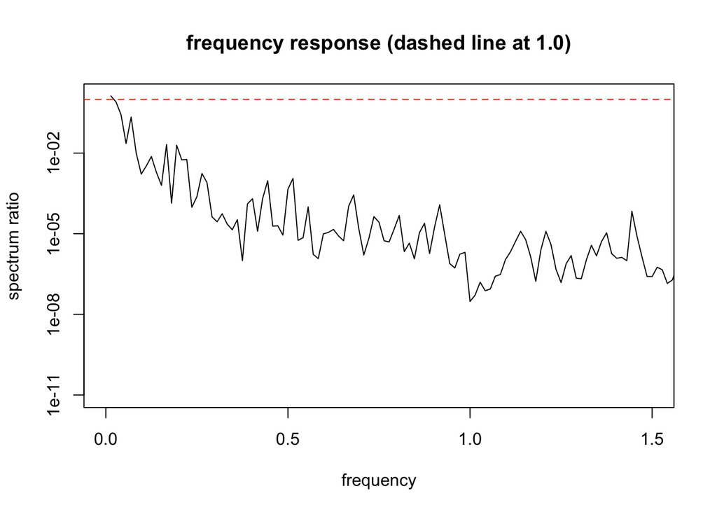

```r
s2 <- spectrum(ts.union(u1_ts,ts(u1_loess$fitted,start=1948,frequency=12)),plot=FALSE)
plot(s2$freq,s2$spec[,2]/s2$spec[,1],type="l",log="y",
  ylab="spectrum ratio", xlab="frequency", xlim=c(0,1.5),
  main="frequency response (dashed line at 1.0)")
abline(h=1,lty="dashed",col="red")
```

For the unemployment data, high frequency variation might be considered “noise” and low frequency variation might be considered trend. A band of mid-range frequencies might be considered to correspond to the business cycle.

### A band pass filter: extract business cycles

Build a smoothing operation in the time domain to extract business cycles, and then look at its frequency response function:

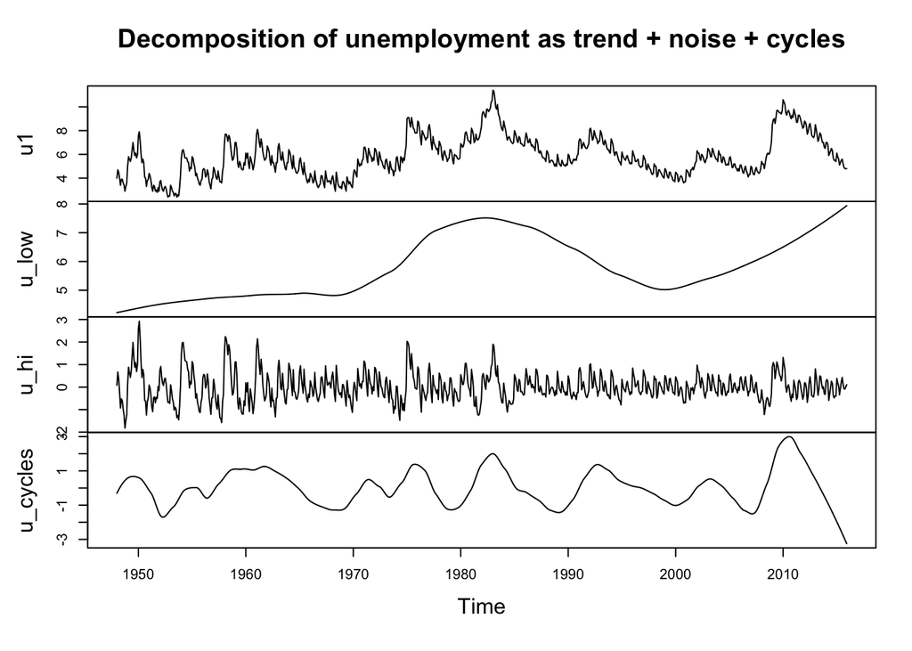

```r
u_low <- ts(loess(u1~date,span=0.5)$fitted,
  start=1948,frequency=12)
u_hi <- ts(u1 - loess(u1~date,span=0.1)$fitted,
  start=1948,frequency=12)
u_cycles <- u1 - u_hi - u_low
plot(ts.union(u1, u_low,u_hi,u_cycles),
  main="Decomposition of unemployment as trend + noise + cycles")
```

The frequency response is

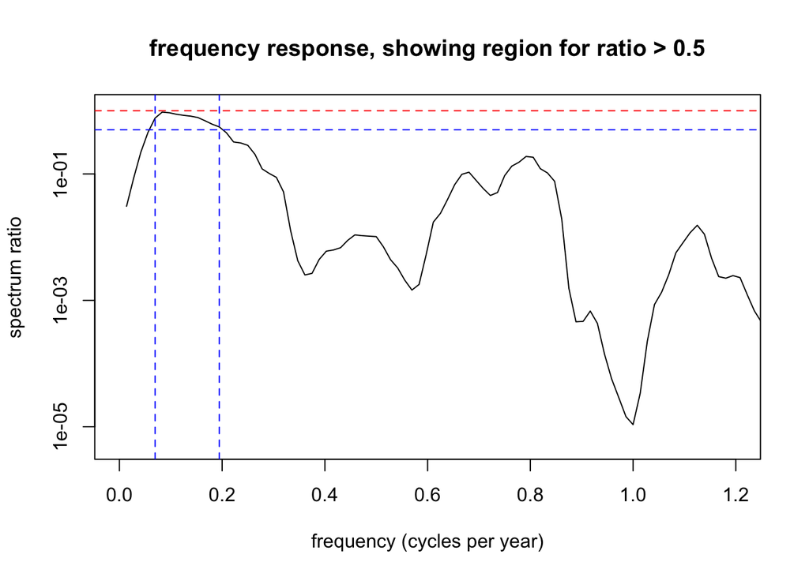

```r
s3 <- spectrum(ts.union(u1_ts,u_cycles),spans=c(3,3),plot=FALSE)
# span --- vector of odd integers giving the widths of modified Daniell smoothers to be used to smooth the periodogram.
plot(s3$freq,s3$spec[,2]/s3$spec[,1],type="l",log="y",
  ylab="spectrum ratio", xlab="frequency (cycles per year)", xlim=c(0,1.2), ylim=c(5e-6,1.1),
  main="frequency response, showing region for ratio > 0.5")
abline(h=1,lty="dashed",col="red")
freq_cycles <- range(s3$freq[s3$spec[,2]/s3$spec[,1]>0.5])
abline(v=freq_cycles,lty="dashed",col="blue")
abline(h=0.5,lty="dashed",col="blue")
```

The horizontal blue line corresponds to power ratio of $.5$. The two verticle lines corresponds to
$$\frac{1}{0.069} \approx 15, \qquad \frac{1}{0.194} \approx 5$$
which means we keep at least half the power for cycles between 5 and 15 year period.

**Comment**: from the business cycles, we infer that recessions happen roughly every 10 years. Some economists argue 3-5 year cycles are also important, but we have filtered them out.

We plot the lower frequencies of a smoothed periodogram for the raw unemployment data to zoom in on frequencies around the business cycle frequency:

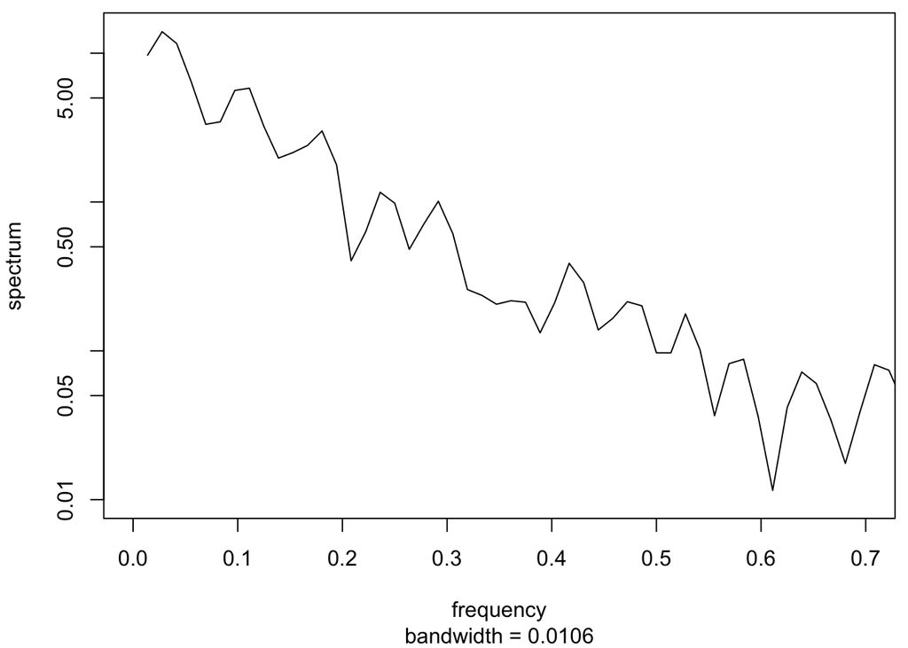

```r
s1 <- spectrum(u1_ts,spans=c(3),plot=FALSE)
par(mai=c(1,0.8,0.1,0.1))
plot(s1,xlim=c(0,0.7),ylim=c(1e-2,max(s1$spec)),main="")
```

The spectrum looks steadily decreasing without clear local peaks that could be resonant frequencies of the economy.